# Bioinformática y Estadística I. Tarea 4

1. Sea $X$ una variable aleatoria Gamma de parámetro de forma $\alpha$ conocido y parámetro de tasa $\lambda$ desconocido, con función de densidad

$$f_{X|\Lambda} (x|\lambda) = \begin{cases}
\frac{ \lambda ^ \alpha}{\Gamma(\alpha)} x^{\alpha-1} e^{-x \lambda},
& x>0;\\
0, & \text{otro caso}.
\end{cases}$$
Encuentre la distribución posterior de $\Lambda$ suponiendo que se tiene una muestra de tamaño $n$ y que, a priori, $\Lambda$ sigue una distribución Gamma$(a, b)$. Luego, la función de densidad a priori es:
$$f_{\Lambda}(\lambda) = \begin{cases}
\frac{ b ^ a}{\Gamma(a)} \lambda^{a-1} e^{-b\lambda}, & x>0;\\
0, & \text{otro caso}.
\end{cases}$$

### Resolucion

#### Distribucion Posterior

$$\begin{gather}
\lambda^{\alpha n}e^{-\lambda\sum^{n}_{i=1}x_i} \times \lambda^{a-1}
e^{-b\lambda}
\\
\rightarrow \lambda^{n\alpha+\alpha-1}e^{-\lambda(b+\sum_{i=1}^nx_i)}
\\
a^* = n\alpha+a
\\
b^* = b + \sum_{i=1}^nx_i
\end{gather}$$

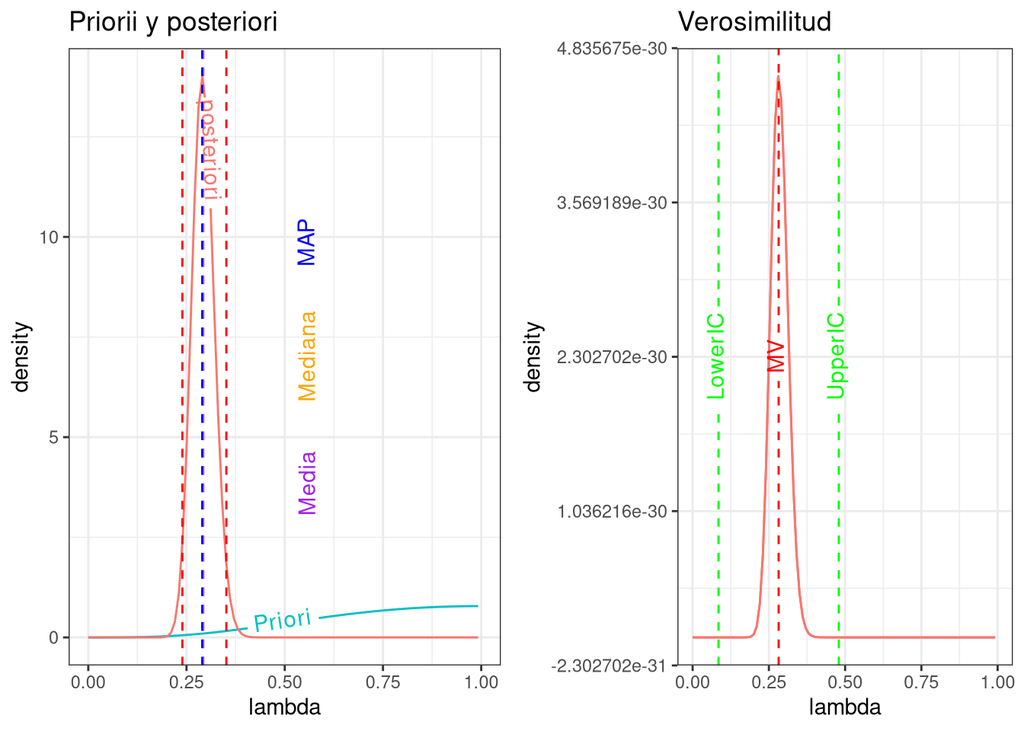

2. Suponga que se tiene una muestra aleatoria de tamaño $n$ de una variable aleatoria Geométrica$(\theta)$. Encuentre la distribución posterior de $\Theta$ considerando que, a priori, $\Theta$ sigue una distribución Beta$(a, b)$. Recuerde que la variable $X$ cuenta el número de fallas hasta el primer éxito, por lo que la función de probabilidad es:

$$f_{X|\Theta}(x|\theta) = \begin{cases}
\theta(1-\theta)^x, & x=0,1,2,...;\\
0 & \text{otro caso}.
\end{cases}$$
$$\begin{gather}\prod_{i=1}^n\theta^n(1-\theta)^{\sum x_i}
\end{gather}$$

$$\begin{gather}
\theta^n(1-\theta)^{\sum x_i} \times
\theta^{\alpha-1}(1-\theta)^{\beta-1}
\\
\rightarrow \theta^{n+\alpha-1}(1-\theta)^{\sum{x_i}+\beta-1}
\\
b^* = \sum_{i=1}^n{x_i}+\beta
\\
a^* = n+\alpha
\end{gather}$$

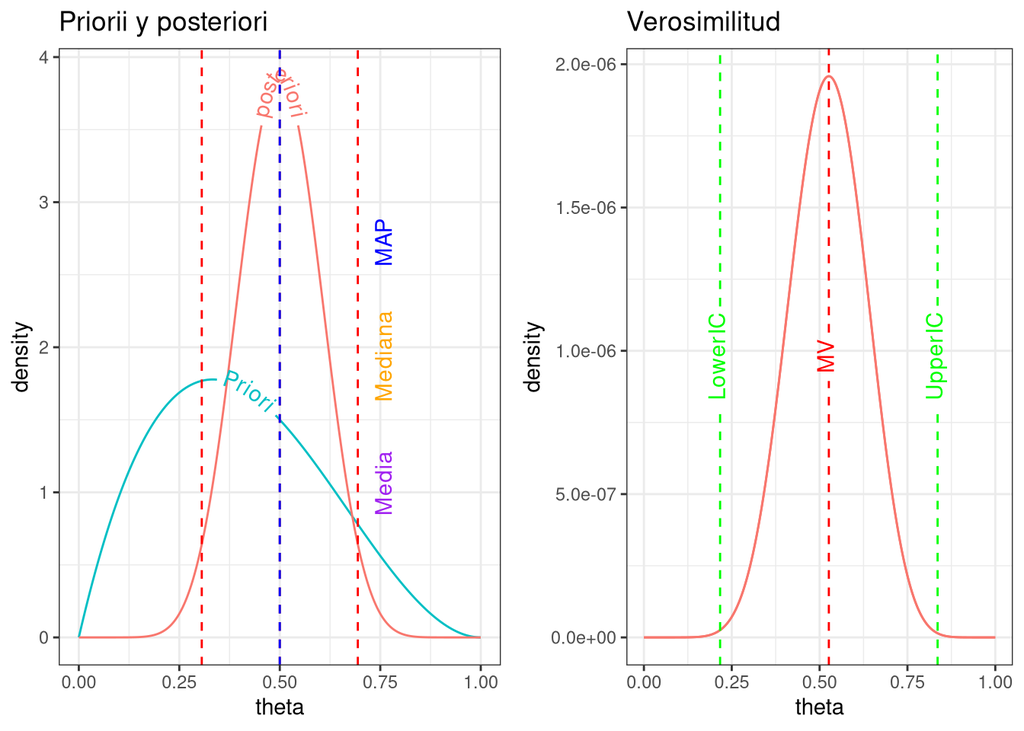

```r
library(ggplot2)
library(dplyr)
library(geomtextpath)
library(hrbrthemes)
library(gridExtra)

# Parametros
set.seed(1600)
n <- 10
a_Priori <- 2
b_Priori <- 3

# Generar valores aleatorios bajo la distribución geométrica
data <- rgeom(n, prob = 0.5)

# Parametros posteriori
a_post <- a_Priori + n
b_post <- b_Priori + sum(data)

# Definir funciones de densidad
Priori_density <- function(theta) {  dbeta(theta, shape1 = a_Priori, shape2 = b_Priori) }
posteriori_density <- function(theta) {  dbeta(theta, shape1 = a_post, shape2 = b_post) }
Verosimilitud_density <- function(theta) {
  Verosimilitud <- 1
  for (i in 1:n) {
    Verosimilitud <- Verosimilitud * theta * (1 - theta)^data[i]
  }
  return(Verosimilitud)
}

# Secuencia de números para el plot
theta_seq <- seq(0, 1, length.out = 500)

# ggplot usa data.frames para la densidad
df_Priori <- data.frame(theta = theta_seq, density = Priori_density(theta_seq), type = "Priori")
df_posteriori <- data.frame(theta = theta_seq, density = posteriori_density(theta_seq), type = "posteriori")
df_Verosimilitud <- data.frame(theta = theta_seq, density = sapply(theta_seq, Verosimilitud_density), type = "Verosimilitud")
df_combined <- rbind(df_Priori, df_posteriori, df_Verosimilitud)

# Requerimientos

MV <- n / (n + sum(data)) # Máxima verosimilitud
SE = sqrt(MV * (1 - MV) / n)
q = qnorm(0.975)
IC_conf = c(MV - q * SE, MV + q * SE)
posteriori_mean <- a_post / (a_post + b_post) # Media
posteriori_med <- qbeta(0.5, a_post, b_post) # Mediana
posteriori_map <- (a_post - 1) / (a_post + b_post - 2) # MAP
cred_lower <- qbeta(0.025, a_post, b_post) # Intervalo de credibilidad
cred_upper <- qbeta(0.975, a_post, b_post)

# Priorii y posteriori
plot1 <- ggplot(df_combined %>% filter(type != "Verosimilitud"), aes(x = theta, y = density, colour = type)) +
  geom_textpath(aes(label = type)) +
  theme_bw() +
  guides(color = 'none') +
  ggtitle("Priorii y posteriori") +
  geom_textvline(xintercept = posteriori_mean, color = 'purple', linetype = 'dashed', label = "Media", hjust = .27, vjust = 4) +
  geom_textvline(xintercept = posteriori_med, color = 'orange', linetype = 'dashed', label = "Mediana", hjust = .5, vjust = 4) +
  geom_textvline(xintercept = posteriori_map, color = 'blue', linetype = 'dashed', label = "MAP", hjust = .7, vjust = 4) +
  geom_vline(xintercept = cred_lower, color = 'red', linetype = 'dashed') +
  geom_vline(xintercept = cred_upper, color = 'red', linetype = 'dashed') +
  xlim(0, 1)

# Verosimilitud
plot2 <- ggplot(df_combined %>% filter(type == "Verosimilitud"), aes(x = theta, y = density, colour = type)) +
  geom_textpath(aes(label = type), hjust = 1.5, vjust = 1.5) +
  theme_bw() +
  guides(color = 'none') +
  ggtitle("Verosimilitud") +
  geom_line() +
  geom_textvline(xintercept = MV, color = 'red', linetype = 'dashed', label = "MV") +
  geom_textvline(xintercept = IC_conf[1], color = 'green', linetype = 'dashed', label = "LowerIC") +
  geom_textvline(xintercept = IC_conf[2], color = 'green', linetype = 'dashed', label = "UpperIC") +
  xlim(0, 1)

# Mostrar ambos gráficos
grid.arrange(plot1, plot2, ncol = 2)
```

3. Sea $X$ una variable aleatoria Binomial Negativa de parámetros $r$ y $\theta$. Encontrar la distribución a posteriori de $\Theta$ suponiendo que se tiene una muestra de tamaño $n$ y que, a priori, $\Theta$ sigue una distribución Beta$(a,b)$. Recuerde que la varaible $X$ cuenta el número de fallas hasta obtener $r$ éxitos, por lo que la función de probabilidad está dada por:
   $$f_{X|\Theta}(x|\theta) = \begin{cases}
   {x+r-1 \choose x} \theta^r(1-\theta)^x, & x=0,1,2,...;\\
   0 & \text{otro caso}.
   \end{cases}$$
   ### Resolucion

#### Verosimilitud

$$\begin{gather}
\prod_{i=1}^n\binom{x_i+r-1}{x_i}\theta^r(1-\theta)^{x_i}\\
\propto \theta^{nr}(1-\theta)^{\sum^{n}_{i=1} x_i}
\end{gather}$$

#### Distribucion Conjunta

$$\begin{gather}
\frac{\theta^{a-1}(1-\theta)^{b-1}}{B(a,b)} \propto
\theta^{a-1}(1-\theta)^{b-1}
\\
\theta^{a-1+nr}(1-\theta)^{b-1+\sum_{i=1}^nx_i}
\\
a^* = a+nr\\
b^* = b+\sum_{i=1}^nx_i
\end{gather}$$

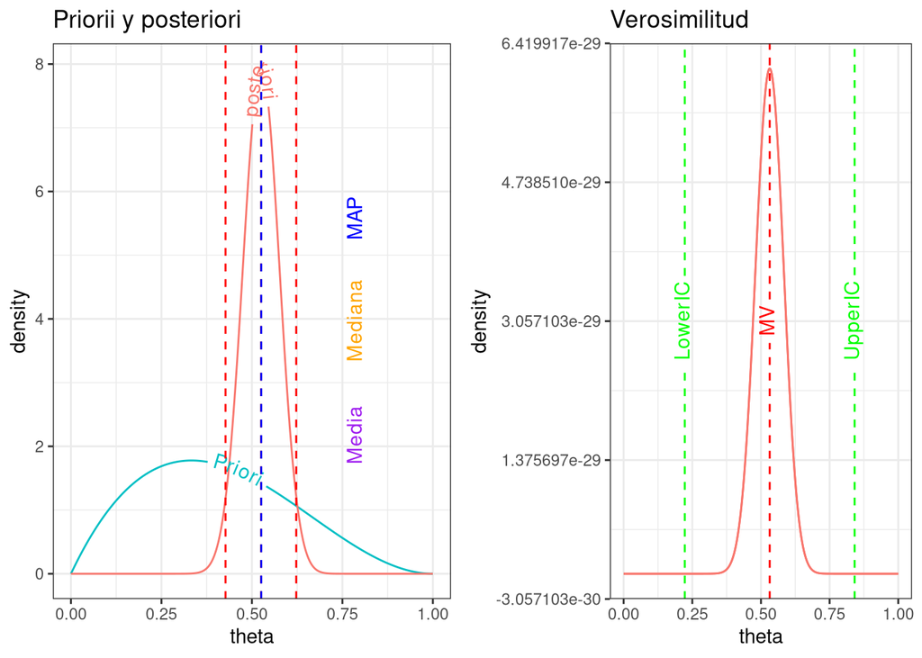

```r
library(ggplot2)
library(dplyr)
library(geomtextpath)
library(hrbrthemes)
library(gridExtra)

# Parametros
set.seed(1600)
n <- 10
r <- 5
a_Priori <- 2
b_Priori <- 3

# Generar valores aleatorios bajo la distribución geométrica
data <- rnbinom(n, size = r, prob = .5)

# Parametros posteriori
a_post <- a_Priori + n*r
b_post <- b_Priori + sum(data)

# Definir funciones de densidad
Priori_density <- function(theta) {  dbeta(theta, shape1 = a_Priori, shape2 = b_Priori) }
posteriori_density <- function(theta) {  dbeta(theta, shape1 = a_post, shape2 = b_post) }
Verosimilitud_density <- function(theta) {
  Verosimilitud <- 1
  for (i in 1:n) {
    Verosimilitud <-Verosimilitud <- Verosimilitud * theta^r * (1 - theta)^data[i]
  }
  return(Verosimilitud)
}

# Secuencia de números para el plot
theta_seq <- seq(0, 1, length.out = 500)

# ggplot usa data.frames para la densidad
df_Priori <- data.frame(theta = theta_seq, density = Priori_density(theta_seq), type = "Priori")
df_posteriori <- data.frame(theta = theta_seq, density = posteriori_density(theta_seq), type = "posteriori")
df_Verosimilitud <- data.frame(theta = theta_seq, density = sapply(theta_seq, Verosimilitud_density), type = "Verosimilitud")
df_combined <- rbind(df_Priori, df_posteriori, df_Verosimilitud)

# Requerimientos
MV <- n * r / (n * r + sum(data)) # Máxima verosimilitud
SE = sqrt(MV * (1 - MV) / n)
q = qnorm(0.975)
IC_conf = c(MV - q * SE, MV + q * SE)
posteriori_mean <- a_post / (a_post + b_post) # Media
posteriori_med <- qbeta(0.5, a_post, b_post) # Mediana
posteriori_map <- (a_post - 1) / (a_post + b_post - 2) # MAP
cred_lower <- qbeta(0.025, a_post, b_post) # Intervalo de credibilidad
cred_upper <- qbeta(0.975, a_post, b_post)

# Priorii y posteriori
plot1 <- ggplot(df_combined %>% filter(type != "Verosimilitud"), aes(x = theta, y = density, colour = type)) +
  geom_textpath(aes(label = type)) +
  theme_bw() +
  guides(color = 'none') +
  ggtitle("Priorii y posteriori") +
  geom_textvline(xintercept = posteriori_mean, color = 'purple', linetype = 'dashed', label = "Media", hjust = .27, vjust = 4) +
  geom_textvline(xintercept = posteriori_med, color = 'orange', linetype = 'dashed', label = "Mediana", hjust = .5, vjust = 4) +
  geom_textvline(xintercept = posteriori_map, color = 'blue', linetype = 'dashed', label = "MAP", hjust = .7, vjust = 4) +
  geom_vline(xintercept = cred_lower, color = 'red', linetype = 'dashed') +
  geom_vline(xintercept = cred_upper, color = 'red', linetype = 'dashed') +
  xlim(0, 1)

# Verosimilitud
plot2 <- ggplot(df_combined %>% filter(type == "Verosimilitud"), aes(x = theta, y = density, colour = type)) +
  geom_textpath(aes(label = type), hjust = 1.5, vjust = 1.5) +
  theme_bw() +
  guides(color = 'none') +
  ggtitle("Verosimilitud") +
  geom_line() +
  geom_textvline(xintercept = MV, color = 'red', linetype = 'dashed', label = "MV") +
  geom_textvline(xintercept = IC_conf[1], color = 'green', linetype = 'dashed', label = "LowerIC") +
  geom_textvline(xintercept = IC_conf[2], color = 'green', linetype = 'dashed', label = "UpperIC") +
  xlim(0, 1)

# Mostrar ambos gráficos
grid.arrange(plot1, plot2, ncol = 2)
```

4. Se desea estimar el parámetro $\lambda$ de una distribución Poisson a partir de una muestra de tamaño $n$. Encuentre la distribución posterior de $\Lambda$ suponiendo que, a priori, $\Lambda\sim \text{Gamma}(\alpha, \beta)$, donde $\alpha$ es parámetro de forma y $\beta$ es parámetro de tasa. Recuerde la función de probabilidad Poisson está dada por:
   $$f_{X|\Lambda}(x|\lambda) = \begin{cases}
   \frac{\lambda^x e^{-\lambda}}{x!}, & x=0,1,2,...;\\
   0 & \text{otro caso}.
   \end{cases}$$

### Resolucion

#### Verosimilitud

$$\begin{gather}
\prod_{i=1}^{n}\frac{\lambda^n{x_i}e^{-\lambda}}{x_i!}
\\
\propto\lambda^{\sum^n_{i=1}}e^{-n\lambda}
\end{gather}$$
#### Distribucion conjunta
$$\frac{\beta^\alpha}{\Gamma(\alpha)}\lambda^{\alpha-1}e^{-\beta\lambda}
\\
\lambda^{\sum_{i=1}^n x_i+\alpha-1}e^{-(n+\beta)\lambda}
\\
\alpha^*= \sum^{n}_{i=1}x_i + \alpha
\\
\beta^* = n+\beta$$

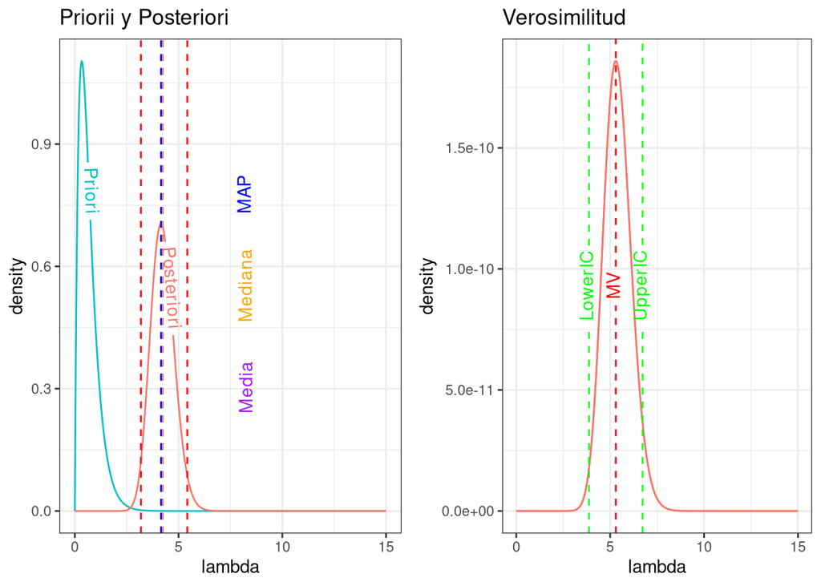

```r
library(ggplot2)
library(dplyr)
library(geomtextpath)
library(hrbrthemes)
library(gridExtra)

# Parámetros Poisson
set.seed(1600)
n <- 10
alpha_Priori <- 2
beta_Priori <- 3

# Generar datos Poisson
data <- rpois(n, lambda = 5)

# Parámetros posteriori
alpha_post <- alpha_Priori + sum(data)
beta_post <- beta_Priori + n

# Definir funciones de densidad
Priori_density <- function(lambda) {  dgamma(lambda, shape = alpha_Priori, rate = beta_Priori) }
posteriori_density <- function(lambda) {  dgamma(lambda, shape = alpha_post, rate = beta_post) }
Verosimilitud_density <- function(lambda) {
  Verosimilitud <- 1
  for (i in 1:n) {
    Verosimilitud <- Verosimilitud * (lambda^data[i] * exp(-lambda)) / factorial(data[i])
  }
  return(Verosimilitud)
}

# Secuencia de números para el plot
lambda_seq <- seq(0, 15, length.out = 500)

# ggplot usa data.frames para la densidad
df_Priori <- data.frame(lambda = lambda_seq, density = Priori_density(lambda_seq), type = "Priori")
df_posteriori <- data.frame(lambda = lambda_seq, density = posteriori_density(lambda_seq), type = "Posteriori")
df_Verosimilitud <- data.frame(lambda = lambda_seq, density = sapply(lambda_seq, Verosimilitud_density), type = "Verosimilitud")
df_combined <- rbind(df_Priori, df_posteriori, df_Verosimilitud)

# Calcular estadísticas clave
MV <- mean(data)  # Máxima verosimilitud para la Poisson
SE <- sqrt(MV / n)
q <- qnorm(0.975)
IC_conf <- c(MV - q * SE, MV + q * SE)
posteriori_mean <- alpha_post / beta_post  # Media
posteriori_med <- qgamma(0.5, alpha_post, beta_post)  # Mediana
posteriori_map <- (alpha_post - 1) / beta_post  # MAP
cred_lower <- qgamma(0.025, alpha_post, beta_post)  # Intervalo de credibilidad
cred_upper <- qgamma(0.975, alpha_post, beta_post)

# Priorii y posteriori
plot1 <- ggplot(df_combined %>% filter(type != "Verosimilitud"), aes(x = lambda, y = density, colour = type)) +
  geom_textpath(aes(label = type)) +
  theme_bw() +
  guides(color = 'none') +
  ggtitle("Priorii y Posteriori") +
  geom_textvline(xintercept = posteriori_mean, color = 'purple', linetype = 'dashed', label = "Media", hjust = .27, vjust = 4) +
  geom_textvline(xintercept = posteriori_med, color = 'orange', linetype = 'dashed', label = "Mediana", hjust = .5, vjust = 4) +
  geom_textvline(xintercept = posteriori_map, color = 'blue', linetype = 'dashed', label = "MAP", hjust = .7, vjust = 4) +
  geom_vline(xintercept = cred_lower, color = 'red', linetype = 'dashed') +
  geom_vline(xintercept = cred_upper, color = 'red', linetype = 'dashed') +
  xlim(0, 15)

# Verosimilitud
plot2 <- ggplot(df_combined %>% filter(type == "Verosimilitud"), aes(x = lambda, y = density, colour = type)) +
  geom_textpath(aes(label = type), hjust = 1.5, vjust = 1.5) +
  theme_bw() +
  guides(color = 'none') +
  ggtitle("Verosimilitud") +
  geom_line() +
  geom_textvline(xintercept = MV, color = 'red', linetype = 'dashed', label = "MV") +
  geom_textvline(xintercept = IC_conf[1], color = 'green', linetype = 'dashed', label = "LowerIC") +
  geom_textvline(xintercept = IC_conf[2], color = 'green', linetype = 'dashed', label = "UpperIC") +
  xlim(0, 15)

# Mostrar ambos gráficos
grid.arrange(plot1, plot2, ncol = 2)
```

5. Sea $X$ una variable aleatoria Normal con media conocida $\mu$ y precisión $\tau$ desconocida, cuya función de densidad está dada por
   $$f_{X|T}(x|\tau) = \sqrt{\frac{\tau}{2\pi}}\exp\left\{-\frac{\tau}{2}
   (x-\mu)^2 \right\}.$$
   Note que la precisión es igual a $\sigma^{-2}$, lo cual implica que, a mayor varianza, menor precisión, y a mayor precisión, menor varianza, puesto que uno es el inverso del otro. Encuentre la función de densidad a posteriori de $T$ a partir de una muestra de tamaño $n$, bajo el supuesto de que $T$ sigue una distribución a priori Gamma$(\alpha, \beta)$, donde $\alpha$ es parámetro de forma y $\beta$ es parámetro de tasa.

### Resolucion

#### Verosimilitud

$$\begin{gather}
\prod_{i=1}^{n}\sqrt{\frac{\tau}{2\pi}}\exp(-\frac{\tau}{2}(x_i-\mu)^2)\propto
\tau^{n/2}\exp(-\frac{\tau}{2}\sum_{i=1}^n(x_i-\mu)^2)
\end{gather}$$
#### Distribucion Conjunta
$$\begin{gather}
\frac{\beta^\alpha}{\Gamma(\alpha)}\lambda^{\alpha-1}e^{-\beta\lambda}
\\
\tau^{n/2+\alpha-1}e^{-\tau(\frac{1}{2}\sum^n_{i=1}(x_i-\mu)^2+\beta)}
\\
\alpha^*=\alpha + \frac{n}{2}
\\
\beta^* =\beta+\frac{1}{2}\sum^n_{i=1}(x_i-\mu)^2
\end{gather}$$

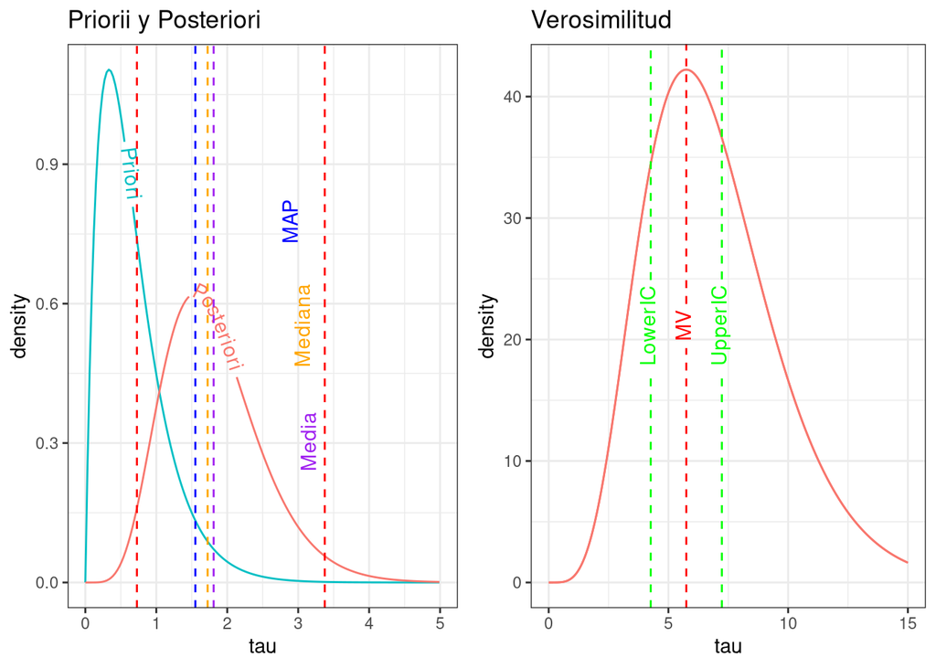

```r
# Parámetros Normal
set.seed(1600)
n <- 10
mu <- 5
alpha_Priori <- 2
beta_Priori <- 3

# Generar datos Normal con precisión desconocida
data <- rnorm(n, mean = mu, sd = 1)

# Parámetros posteriori
alpha_post <- alpha_Priori + n / 2
beta_post <- beta_Priori + 0.5 * sum((data - mu)^2)

# Definir funciones de densidad
Priori_density <- function(tau) {  dgamma(tau, shape = alpha_Priori, rate = beta_Priori) }
posteriori_density <- function(tau) {  dgamma(tau, shape = alpha_post, rate = beta_post) }
Verosimilitud_density <- function(tau) {
  Verosimilitud <- 1
  for (i in 1:n) {
    Verosimilitud <- Verosimilitud * sqrt(tau) * exp(-0.5 * tau * (data[i] - mu)^2)
  }
  return(Verosimilitud)
}

# Secuencia de números para el plot
tau_seq <- seq(0, 15, length.out = 500)

# ggplot usa data.frames para la densidad
df_Priori <- data.frame(tau = tau_seq, density = Priori_density(tau_seq), type = "Priori")
df_posteriori <- data.frame(tau = tau_seq, density = posteriori_density(tau_seq), type = "Posteriori")
df_Verosimilitud <- data.frame(tau = tau_seq, density = sapply(tau_seq, Verosimilitud_density), type = "Verosimilitud")
df_combined <- rbind(df_Priori, df_posteriori, df_Verosimilitud)

# Calcular estadísticas clave
MV <- n / sum((data - mu)^2)  # Máxima verosimilitud para la precisión
SE <- sqrt(MV / n)
q <- qnorm(0.975)
IC_conf <- c(MV - q * SE, MV + q * SE)
posteriori_mean <- alpha_post / beta_post  # Media
posteriori_med <- qgamma(0.5, alpha_post, beta_post)  # Mediana
posteriori_map <- (alpha_post - 1) / beta_post  # MAP
cred_lower <- qgamma(0.025, alpha_post, beta_post)  # Intervalo de credibilidad
cred_upper <- qgamma(0.975, alpha_post, beta_post)

# Priorii y posteriori
plot1 <- ggplot(df_combined %>% filter(type != "Verosimilitud"), aes(x = tau, y = density, colour = type)) +
  geom_textpath(aes(label = type)) +
  theme_bw() +
  guides(color = 'none') +
  ggtitle("Priorii y Posteriori") +
  geom_textvline(xintercept = posteriori_mean, color = 'purple', linetype = 'dashed', label = "Media", hjust = .27, vjust = 4) +
  geom_textvline(xintercept = posteriori_med, color = 'orange', linetype = 'dashed', label = "Mediana", hjust = .5, vjust = 4) +
  geom_textvline(xintercept = posteriori_map, color = 'blue', linetype = 'dashed', label = "MAP", hjust = .7, vjust = 4) +
  geom_vline(xintercept = cred_lower, color = 'red', linetype = 'dashed') +
  geom_vline(xintercept = cred_upper, color = 'red', linetype = 'dashed') +
  xlim(0, 5)

# Verosimilitud
plot2 <- ggplot(df_combined %>% filter(type == "Verosimilitud"), aes(x = tau, y = density, colour = type)) +
  geom_textpath(aes(label = type), hjust = 1.5, vjust = 1.5) +
  theme_bw() +
  guides(color = 'none') +
  ggtitle("Verosimilitud") +
  geom_line() +
  geom_textvline(xintercept = MV, color = 'red', linetype = 'dashed', label = "MV") +
  geom_textvline(xintercept = IC_conf[1], color = 'green', linetype = 'dashed', label = "LowerIC") +
  geom_textvline(xintercept = IC_conf[2], color = 'green', linetype = 'dashed', label = "UpperIC") +
  xlim(0, 15)

# Mostrar ambos gráficos
grid.arrange(plot1, plot2, ncol = 2)
```

6. Sea $X$ una variable aleatoria Exponencial con parámetro de tasa $\lambda$ y con función de densidad:
$$f_{X|\Lambda} (x|\lambda) = \begin{cases}
\lambda e^{-\lambda x }, & x>0;\\
0, & \text{otro caso}.
\end{cases}$$
Encuentre la función de densidad a posteriori de $\Lambda$ a partir de una muestra de tamaño $n$, bajo el supuesto de que $\Lambda$ sigue una distribución a priori Gamma$(\alpha, \beta)$, donde $\alpha$ es parámetro de forma y $\beta$ es parámetro de tasa. ### Resolucion

#### Verosimilitud

$$\begin{gather}
\prod_{i=1}^n\lambda e^{-\lambda x_i}
= \lambda^n e^{-\lambda \sum^n_{i=1}x_i}
\end{gather}$$
#### Distribucion conjunta
$$\begin{gather}
\frac{\beta^\alpha}{\Gamma(\alpha)}\lambda^{\alpha-1}e^{-\beta\lambda}
\\
f_{\Lambda|X}\propto\lambda^{n+\alpha-1}e^{-\lambda(\sum^n_{i=1}x_i+\beta)}
\\
\alpha^*= \alpha+n
\\
\beta^*= \beta + \sum^n_{i=1}x_i
\end{gather}$$

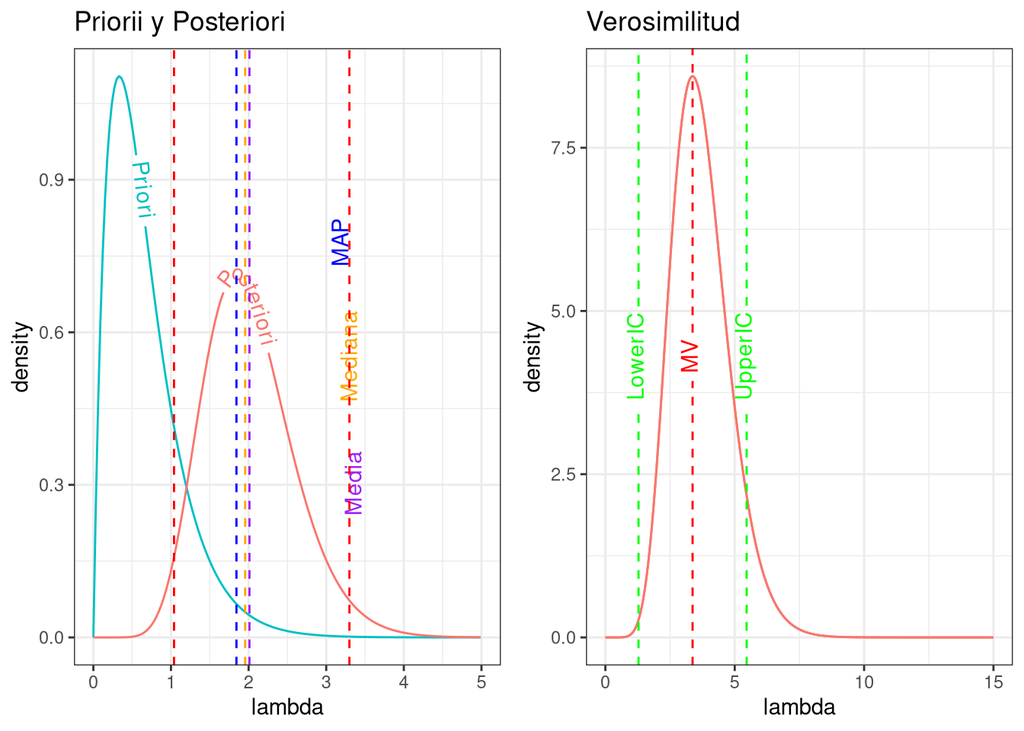

```r
library(ggplot2)
library(dplyr)
library(geomtextpath)
library(hrbrthemes)
library(gridExtra)

# Parámetros para la Exponencial
set.seed(1600)
n <- 10
alpha_Priori <- 2
beta_Priori <- 3

# Generar datos Exponenciales
data <- rexp(n, rate = 4)

# Parámetros posteriori
alpha_post <- alpha_Priori + n
beta_post <- beta_Priori + sum(data)

# Definir funciones de densidad
Priori_density <- function(lambda) {  dgamma(lambda, shape = alpha_Priori, rate = beta_Priori) }
posteriori_density <- function(lambda) {  dgamma(lambda, shape = alpha_post, rate = beta_post) }
Verosimilitud_density <- function(lambda) {
  Verosimilitud <- 1
  for (i in 1:n) {
    Verosimilitud <- Verosimilitud * lambda * exp(-lambda * data[i])
  }
  return(Verosimilitud)
}

# Secuencia de números para el plot
lambda_seq <- seq(0, 15, length.out = 500)

# ggplot usa data.frames para la densidad
df_Priori <- data.frame(lambda = lambda_seq, density = Priori_density(lambda_seq), type = "Priori")
df_posteriori <- data.frame(lambda = lambda_seq, density = posteriori_density(lambda_seq), type = "Posteriori")
df_Verosimilitud <- data.frame(lambda = lambda_seq, density = sapply(lambda_seq, Verosimilitud_density), type = "Verosimilitud")
df_combined <- rbind(df_Priori, df_posteriori, df_Verosimilitud)

# Calcular estadísticas clave
MV <- 1 / mean(data)  # Máxima verosimilitud para la Exponencial
SE <- MV / sqrt(n)
q <- qnorm(0.975)
IC_conf <- c(MV - q * SE, MV + q * SE)
posteriori_mean <- alpha_post / beta_post  # Media
posteriori_med <- qgamma(0.5, alpha_post, beta_post)  # Mediana
posteriori_map <- (alpha_post - 1) / beta_post  # MAP
cred_lower <- qgamma(0.025, alpha_post, beta_post)  # Intervalo de credibilidad
cred_upper <- qgamma(0.975, alpha_post, beta_post)

# Priorii y posteriori
plot1 <- ggplot(df_combined %>% filter(type != "Verosimilitud"), aes(x = lambda, y = density, colour = type)) +
  geom_textpath(aes(label = type)) +
  theme_bw() +
  guides(color = 'none') +
  ggtitle("Priorii y Posteriori") +
  geom_textvline(xintercept = posteriori_mean, color = 'purple', linetype = 'dashed', label = "Media", hjust = .27, vjust = 4) +
  geom_textvline(xintercept = posteriori_med, color = 'orange', linetype = 'dashed', label = "Mediana", hjust = .5, vjust = 4) +
  geom_textvline(xintercept = posteriori_map, color = 'blue', linetype = 'dashed', label = "MAP", hjust = .7, vjust = 4) +
  geom_vline(xintercept = cred_lower, color = 'red', linetype = 'dashed') +
  geom_vline(xintercept = cred_upper, color = 'red', linetype = 'dashed') +
  xlim(0, 5)

# Verosimilitud
plot2 <- ggplot(df_combined %>% filter(type == "Verosimilitud"), aes(x = lambda, y = density, colour = type)) +
  geom_textpath(aes(label = type), hjust = 1.5, vjust = 1.5) +
  theme_bw() +
  guides(color = 'none') +
  ggtitle("Verosimilitud") +
  geom_line() +
  geom_textvline(xintercept = MV, color = 'red', linetype = 'dashed', label = "MV") +
  geom_textvline(xintercept = IC_conf[1], color = 'green', linetype = 'dashed', label = "LowerIC") +
  geom_textvline(xintercept = IC_conf[2], color = 'green', linetype = 'dashed', label = "UpperIC") +
  xlim(0, 15)

# Mostrar ambos gráficos
grid.arrange(plot1, plot2, ncol = 2)
```

Nota: Para cada ejercicio, además de encontrar la distribución posterior, haga lo siguiente:

1. Genere $n$ datos sintéticos.
2. Grafique la función de densidad a priori.
3. Grafique la función de densidad a posteriori.
4. Grafique la función de de verosimilitud.
5. Sobre la gráfica de la función de verosimilitud, grafique el estimador de máxima verosimilitud y el intervalo del 95% de confianza.
6. Sobre la gráfica de la distribución posterior, grafique la media a posteriori, la mediana a posteriori, el MAP, y un intervalo de credibilidad de 95%.
7. Compare los resultados de ambos métodos. Juegue con el valor de $n$ y los parámetros a priori para ver sus efectos sobre la inferencia. No es necesario que redacte nada sobre este último punto.